# Actividad5_proyeccion_nacimientos

## LIBRERÍAS

Lo primero que hacemos es importar las lbrerías que vamos a utilizar en el proyecto, las cuales detallamos a continuación:

| **Librería** | **Justificación** |
| --- | --- |
| **pandas** | Permite la gestión, exploración y limpieza de datos provenientes de archivos CSV, facilitando la preparación del dataset para el modelado. |
| **numpy** | Proporciona operaciones matemáticas y estructuras numéricas optimizadas necesarias para el procesamiento de datos en Machine Learning. |
| **scikit-learn** | Utilizada para el preprocesamiento, la construcción de modelos de regresión, la validación y el cálculo de métricas de desempeño. Es la librería estándar para Machine Learning clásico. |
| **matplotlib** | Se emplea para generar gráficos que permiten visualizar resultados, tendencias y proyecciones. |
| **seaborn** | Facilita la creación de visualizaciones estadísticas más estéticas y comparativas, como gráficos por sexo y departamento. |
| **warnings** | Utilizada para suprimir advertencias irrelevantes y mantener el notebook más limpio y legible. |

```python
# Importar librerías

import pandas as pd
import numpy as np
import matplotlib.pyplot as plt
import seaborn as sns
from sklearn.model_selection import train_test_split
from sklearn.linear_model import LinearRegression
from sklearn.ensemble import RandomForestRegressor
from sklearn.compose import ColumnTransformer
from sklearn.pipeline import Pipeline
from sklearn.preprocessing import OneHotEncoder
from sklearn.impute import SimpleImputer
from sklearn.metrics import mean_absolute_error, mean_squared_error, r2_score
```

## TRATAMIENTO DE DATOS

Luego de descargar los archivos del servicio del DANE, realizamos un primera modificación en la que agregamos la columna 'DEPARTAMENTO' e incluimos el nombre del departamento ya que los archivos solo cuentan con un código numérico para identificar los departamentos. que nos es muy claro al momento de presentarlo en una gráfica. Además eliminamos varias columnas que consideramos innecesarias - "Fecha de nacimiento de la madre", "Nivel educativo de la madre", "APGR1", etc -.

A continuación se cargaron los archivos CSV ya depurados correspondientes a los años 2020, 2021, 2022 y 2023 usando pandas. Los archivos se unieron en un solo DataFrame para trabajar con la información completa, agrupados para obtener el conteo de nacimientos.

```
Columnas: Index(['COD_DPTO', 'DEPARTAMENTO', 'GENERO', 'SEXO', 'PESO_NAC', 'ANO', 'MES'], dtype='object')
```

```
  DEPARTAMENTO   ANO  MES     GENERO  NACIMIENTOS
0     Amazonas  2020    1   Femenino           44
1     Amazonas  2020    1  Masculino           55
2     Amazonas  2020    2   Femenino           39
3     Amazonas  2020    2  Masculino           45
4     Amazonas  2020    3   Femenino           41
```

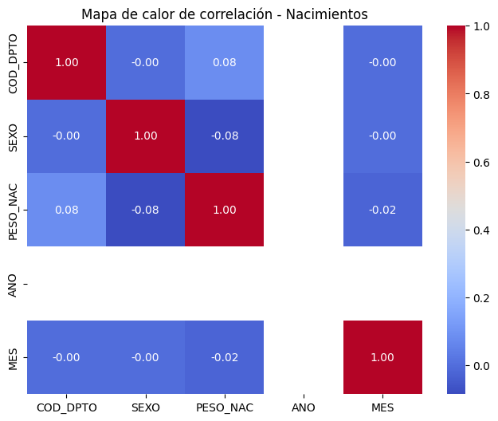

```python
# Cargar datos 2020–2023

files = {
    2020: "sample_data/nacimientos2020.csv",
    2021: "sample_data/nacimientos2021.csv",
    2022: "sample_data/nacimientos2022.csv",
    2023: "sample_data/nacimientos2023.csv"
}

dfs = []
for year, file in files.items():
    df = pd.read_csv(file, sep=None, engine="python")
    dfs.append(df)

df = pd.concat(dfs, ignore_index=True)

# Ver columnas reales
print("Columnas:", df.columns)


# Agrupar datos para obtener conteo de nacimientos


df_agg = df.groupby(
    ["DEPARTAMENTO", "ANO", "MES", "GENERO"]
).size().reset_index(name="NACIMIENTOS")

print(df_agg.head())


# Cargar datos para heatmap de correlación
df = pd.read_csv('sample_data/nacimientos2023.csv', sep=';')

# Seleccionar solo columnas numéricas relevantes
cols_numericas = ['COD_DPTO', 'SEXO', 'PESO_NAC', 'ANO', 'MES']

df_num = df[cols_numericas]

# Matriz de correlación
corr = df_num.corr()

# Graficar heatmap
plt.figure(figsize=(8,6))
sns.heatmap(corr, annot=True, fmt=".2f", cmap="coolwarm")
plt.title("Mapa de calor de correlación - Nacimientos")
plt.show()
```

## DEFINICIÓN DE VARIABLES

La predicción del número de nacimientos puede enriquecerse con múltiples factores demográficos, sociales y temporales. Dado que el proyecto utiliza datos disponibles para los años 2020–2023, se seleccionan variables que son consistentes, comparables y disponibles para todos los departamentos. El modelo se basa en una estructura temporal de los datos (año, mes), en la distribución por departamentos, y en la relación histórica del número de nacimientos a lo largo del tiempo. Es por esto que la matriz de correlación no juega un papel muy importante, en nuestro caso, para la definición de variables.

- Variable dependiente (salida): Nacimientos

Variable numérica continua (Es la variable que se desea predecir para el año 2024.)

- Variables independientes (entrada)

A continuación, se seleccionan variables relevantes, realistas y adecuadas para el enfoque del proyecto.

1. Año

Numérica. Indica el año al que corresponde el registro (2020, 2021, 2022, 2023). Asícapturamos tendencias temporales (crecimiento, descenso, recuperación post-pandemia).

2. Departamento

Categórica. Cada departamento tiene características demográficas distintas (densidad poblacional, fecundidad, urbanización). Permite al modelo aprender las diferencias estructurales entre territorios.

```python
# Definir variables (X = entrada, y = salida)

categorical_features = ["DEPARTAMENTO", "GENERO"]
numeric_features = ["ANO", "MES"]
target = "NACIMIENTOS"

X = df_agg[categorical_features + numeric_features]
y = df_agg[target]


# Separar entrenamiento y validación

X_train, X_val, y_train, y_val = train_test_split(
    X, y, test_size=0.25, random_state=42
)


# Preprocesamiento (OneHot + Imputación)

preprocessor = ColumnTransformer(
    transformers=[
        ("num", SimpleImputer(strategy="median"), numeric_features),
        ("cat", Pipeline([
            ("imputer", SimpleImputer(strategy="most_frequent")),
            ("encoder", OneHotEncoder(handle_unknown="ignore"))
        ]), categorical_features),
    ]
)
```

## MODELOS

Para este proyecto se eligieron dos modelos de Machine Learning —Regresión Lineal y Random Forest Regressor— debido a la naturaleza del problema y al tipo de datos disponibles.

1. Regresión Lineal

La Regresión Lineal se seleccionó como modelo base porque es un modelo adecuado cuando se busca analizar la relación entre variables como año, mes, y departamento.

2. Random Forest Regressor

El modelo Random Forest se eligió porque es capaz de capturar patrones más complejos que la regresión lineal, incluyendo relaciones no lineales entre variables. Maneja mejor la variabilidad entre departamentos. Random Forest suele obtener un mayor desempeño y se convierte en una excelente opción para modelar patrones reales en los nacimientos.

```python
# Modelos

lr_model = Pipeline([
    ("preprocessor", preprocessor),
    ("model", LinearRegression())
])

rf_model = Pipeline([
    ("preprocessor", preprocessor),
    ("model", RandomForestRegressor(n_estimators=300, random_state=42))
])


# Entrenar modelos

lr_model.fit(X_train, y_train)
rf_model.fit(X_train, y_train)
```

```
Pipeline(steps=[('preprocessor',
                 ColumnTransformer(transformers=[('num',
                                                  SimpleImputer(strategy='median'),
                                                  ['ANO', 'MES']),
                                                 ('cat',
                                                  Pipeline(steps=[('imputer',
                                                                   SimpleImputer(strategy='most_frequent')),
                                                                  ('encoder',
                                                                   OneHotEncoder(handle_unknown='ignore'))]),
                                                  ['DEPARTAMENTO',
                                                   'GENERO'])])),
                ('model',
                 RandomForestRegressor(n_estimators=300, random_state=42))])
```

## EVALUACIÓN DE LOS MODELOS Y RESULTADOS

Los dos modelos evaluados presentan buen rendimiento, pero con diferencias importantes en precisión:

**Regresión Lineal**

MAE: 67.20

RMSE: 101.12

R²: 0.9839

La Regresión Lineal logra explicar más del 98% de la variabilidad del número de nacimientos. Sin embargo, sus errores (MAE y RMSE) son relativamente altos comparados con el modelo Random Forest, indicando que no captura completamente patrones más complejos del comportamiento real.

**Random Forest**

MAE: 35.89

RMSE: 55.59

R²: 0.9951

El modelo Random Forest muestra un desempeño claramente superior: reduce a la mitad los errores de predicción frente a la Regresión Lineal. Explica más del 99.5% de la variación en los nacimientos. Esto demuestra que Random Forest es más adecuado para este problema, pues captura relaciones no lineales entre año, mes, sexo y departamento.

```
--- Regresión Lineal ---
MAE: 67.19555738106196
RMSE: 101.12065978334954
R²: 0.9839055446015247

--- Random Forest ---
MAE: 35.887824074074075
RMSE: 55.59498368645396
R²: 0.9951351695275904

Modelo seleccionado: Random Forest
```

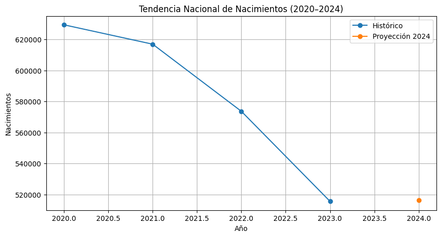

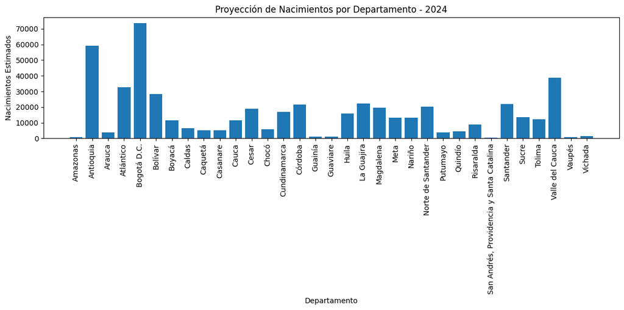

```
Predicción total Colombia 2024:
    ANO  PREDICCION
0  2024   516202.63

Tabla por departamento 2024:
  DEPARTAMENTO    PREDICCION
0     Amazonas    965.150000
1    Antioquia  59384.510000
2       Arauca   4017.646667
3    Atlántico  32840.736667
4  Bogotá D.C.  73723.426667
```

```python
# Evaluación

def evaluar(modelo, nombre):
    pred = modelo.predict(X_val)
    mae = mean_absolute_error(y_val, pred)
    rmse = mean_squared_error(y_val, pred) ** 0.5
    r2 = r2_score(y_val, pred)

    print(f"\n--- {nombre} ---")
    print("MAE:", mae)
    print("RMSE:", rmse)
    print("R²:", r2)

    return mae, rmse, r2

eval_lr = evaluar(lr_model, "Regresión Lineal")
eval_rf = evaluar(rf_model, "Random Forest")

# Elegir mejor modelo (menor RMSE)
best_model = rf_model if eval_rf[1] < eval_lr[1] else lr_model
print("\nModelo seleccionado:",
      "Random Forest" if best_model == rf_model else "Regresión Lineal")



# Crear dataset 2024 (todos los departamentos y meses)

departamentos = df["DEPARTAMENTO"].unique()
generos = df["GENERO"].unique()

pred_2024 = []
for dep in departamentos:
    for gen in generos:
        for mes in range(1, 13):
            pred_2024.append([dep, gen, 2024, mes])

pred_2024 = pd.DataFrame(pred_2024, columns=["DEPARTAMENTO", "GENERO", "ANO", "MES"])

# Predicciones 2024
pred_2024["PREDICCION"] = best_model.predict(pred_2024)

# Para gráfico por departamento
pred_depto = pred_2024.groupby("DEPARTAMENTO")["PREDICCION"].sum().reset_index()



# Gráfico: Tendencia Nacional 2020–2023 + Predicción 2024

trend = df_agg.groupby("ANO")["NACIMIENTOS"].sum().reset_index()
trend_2024 = pred_2024.groupby("ANO")["PREDICCION"].sum().reset_index()

plt.figure(figsize=(10,5))
plt.plot(trend["ANO"], trend["NACIMIENTOS"], marker='o', label="Histórico")
plt.plot([2024], trend_2024["PREDICCION"], marker='o', label="Proyección 2024")
plt.title("Tendencia Nacional de Nacimientos (2020–2024)")
plt.xlabel("Año")
plt.ylabel("Nacimientos")
plt.legend()
plt.grid(True)
plt.show()


# Gráfico por departamento (Barras)

plt.figure(figsize=(12,6))
plt.bar(pred_depto["DEPARTAMENTO"], pred_depto["PREDICCION"])
plt.xticks(rotation=90)
plt.title("Proyección de Nacimientos por Departamento - 2024")
plt.xlabel("Departamento")
plt.ylabel("Nacimientos Estimados")
plt.tight_layout()
plt.show()


# Resultados finales

print("\nPredicción total Colombia 2024:")
print(trend_2024)

print("\nTabla por departamento 2024:")
print(pred_depto.head())
```

## PROYECCIÓN NACIONAL DE NACIMIENTOS 2024

El modelo seleccionando (Random Forest) estima que en 2024 habrá aproximadamente 516.203 nacimientos en Colombia.

**Tendencia Nacional de Nacimientos**

Esta gráfica muestra la evolución del total de nacimientos en Colombia desde 2020 hasta 2023, junto con la proyección realizada para 2024. Se observa que hay una tendencia descendente constante, coherente con fenómenos recientes como la reducción de la tasa de natalidad, los cambios socioeconómicos, y los efectos post-pandemia.

El modelo predice aproximadamente 516.200 nacimientos, una cifra muy similar a la observada en 2023, lo que indica que la caída fuerte parece estabilizarse.

**Proyección de Nacimientos por Departamento**

La gráfica de barras muestra la estimación de nacimientos por departamento para 2024. Se observan diferencias marcadas entre regiones, lo cual es consistente con las poblaciones reales de cada territorio.

Antioquia (~59.000)

Valle del Cauca (~38.000)

Atlántico (~33.000)

Esto refleja la distribución demográfica del país: los departamentos con mayor urbanización concentran más nacimientos.